# Comparing outputs from lefser, lefse-conda, and lefse-galaxy using the same dataset (zeller14)

```r
library(lefser)
library(SummarizedExperiment)
library(dplyr)
library(ggplot2)
library(devtools)
library(tibble)
library(tidyr)
library(magrittr)
library(readr)
library(VennDiagram)
library(purrr)
```

# Introduction

In this document, I compare the output from lefse through different applications:

- lefser (R package)
- lefse-conda (command line)
- lefse-galaxy (from the galaxy platfrom)

# Run lefse independently with the three applications (R, conda, galaxy)

## Running lefse in R (lefser)

Prepare data with TSS normalization. Lefse uses this same normalization step.

```r
data('zeller14')
se <- zeller14[,zeller14$study_condition != 'adenoma']
rownames(se) <- sub('^.+([a-z]__.+$)', '\\1', rownames(se))

colData(se)[['study_condition']] <- factor(
    colData(se)[['study_condition']], levels = c('control', 'CRC')
)

abundances <- assay(se)
abundances_tss <- apply(abundances, 2, function(x) x / sum(x) * 1e6)
assays(se)[[2]] <- abundances_tss
names(assays(se))[2] <- "tss"
se
```

```
## class: SummarizedExperiment
## dim: 1585 157
## metadata(3): experimentData annotation protocolData
## assays(2): exprs tss
## rownames(1585): k__Bacteria k__Viruses ... g__Variovorax
##   s__Variovorax_unclassified
## rowData names(0):
## colnames(157): CCIS00146684ST-4-0 CCIS00281083ST-3-0 ... MMPU84450604ST
##   MMPU99077057ST
## colData names(22): subjectID body_site ... curator NCBI_accession
```

Perform the analysis with the `lefser` function:

```r
lefser_output <- lefser(
    se, kruskal.threshold = 0.05, wilcox.threshold = 0.05,
    groupCol = 'study_condition', blockCol = 'age_category', assay = 2L
) %>%
    mutate(app_name = 'lefser') %>%
    arrange(scores) %>%
    rename(feature = Names, lefser_LDA = scores)

head(lefser_output)
```

```
##                         feature lefser_LDA app_name
## 1               g__Ruminococcus  -3.517764   lefser
## 2            o__Lactobacillales  -3.258332   lefser
## 3           f__Streptococcaceae  -3.203283   lefser
## 4              t__GCF_000159975  -2.921151   lefser
## 5 s__Ruminococcus_sp_5_1_39BFAA  -2.921151   lefser
## 6         s__Eubacterium_hallii  -2.827849   lefser
```

## Running lefse-conda (command line)

### lefse-conda installation and version

Note: I installed lefse following the instructions from [this site](https://github.com/biobakery/conda-biobakery) after installing conda.

```bash
## Add channels
conda config --add channels defaults
conda config --add channels bioconda
conda config --add channels conda-forge
conda config --add channels biobakery

## Install lefse
conda create -n lefse
conda activate lefse
conda install -c biobakery lefse
```

Conda and lefse versions:

```bash
conda --version
#> conda 4.11.0

conda list | grep -e "lefse"
# packages in environment at /home/samuel/miniconda3/envs/lefse:
#> lefse                     1.1.2              pyhdfd78af_0    bioconda
```

### Run lefse-conda

1. Generate a tabular dataset (zeller14) compatible with lefse-conda and lefse-galaxy using the `get_dataset.R` script.
2. Run the script `run_lefse.sh` (linux) with the following parameters:

```bash
## In general
## ./run_lefse.sh <path/to/conda/activate> <env_name> <path/to/Rscript>

## in my case (Samuel)
./run_lefse.sh ~/miniconda3/bin/activate lefse ~/bin/Rscript
```

Note: All script files, `get_dataset.R` and `run_lefse.sh`, and this rmarkdown document must be in the same directory.

### Import output from lefse-conda into R

```r
col_names <- c(
    'feature', 'log_hi_class_avg', 'class', 'lefse_conda_LDA', 'pval'
)
lefse_conda <- readr::read_tsv(
    'zeller14.res', show_col_types = FALSE, col_names = FALSE
) %>%
    set_colnames(col_names) %>%
    filter(!is.na(lefse_conda_LDA)) %>%
    mutate(
        lefse_conda_LDA = ifelse(
            class == 'control', -lefse_conda_LDA, lefse_conda_LDA
        ),
        app_name = 'lefse_conda'
    ) %>%
    arrange(lefse_conda_LDA)

head(lefse_conda)
```

```
## # A tibble: 6 × 6
##   feature                  log_hi_class_avg class lefse_conda_LDA pval  app_name
##   <chr>                               <dbl> <chr>           <dbl> <chr> <chr>
## 1 g__Ruminococcus                      4.16 cont…           -3.51 0.00… lefse_c…
## 2 o__Lactobacillales                   3.72 cont…           -3.24 0.00… lefse_c…
## 3 f__Streptococcaceae                  3.62 cont…           -3.17 0.00… lefse_c…
## 4 s__Ruminococcus_sp_5_1_…             3.47 cont…           -2.88 0.00… lefse_c…
## 5 t__GCF_000159975                     3.47 cont…           -2.88 0.00… lefse_c…
## 6 t__GCF_000173975                     3.32 cont…           -2.82 5.13… lefse_c…
```

## Running lefse from galaxy

I used the `zeller14_nosub.txt` file (no subjects included) as input for lefse from the galaxy platform of the Huttenhower lab at https://huttenhower.sph.harvard.edu/galaxy/

alpha were 0.05 for both KW and Wilcox, 2.0 for LDA. TSS normalization was applied as well.

I’ll just import the output:

```r
col_names <- c(
    'feature', 'log_hi_class_avg', 'class', 'lefse_galaxy_LDA', 'pval'
)
lefse_galaxy <- read_tsv(
    "lefse_gal_all_vs_all.res", col_names = FALSE, show_col_types = FALSE
) %>%
    set_colnames(col_names) %>%
    filter(!is.na(lefse_galaxy_LDA)) %>%
    mutate(
        lefse_galaxy_LDA = ifelse(
            class == "control", -lefse_galaxy_LDA, lefse_galaxy_LDA
        ),
        app_name = 'lefse_galaxy'
    )

head(lefse_galaxy)
```

```
## # A tibble: 6 × 6
##   feature                 log_hi_class_avg class lefse_galaxy_LDA pval  app_name
##   <chr>                              <dbl> <chr>            <dbl> <chr> <chr>
## 1 s__Clostridium_symbios…             2.19 CRC               2.09 2.15… lefse_g…
## 2 g__Oscillibacter                    2.99 CRC               2.52 0.00… lefse_g…
## 3 t__GCF_000153885                    2.84 cont…            -2.23 0.00… lefse_g…
## 4 t__Clostridium_symbios…             2.19 CRC               2.09 2.15… lefse_g…
## 5 t__GCF_000185525                    2.61 cont…            -2.19 9.04… lefse_g…
## 6 f__Oscillospiraceae                 2.99 CRC               2.52 0.00… lefse_g…
```

# Comparison of lefse-conda with lefser

## Number of features reported as significant

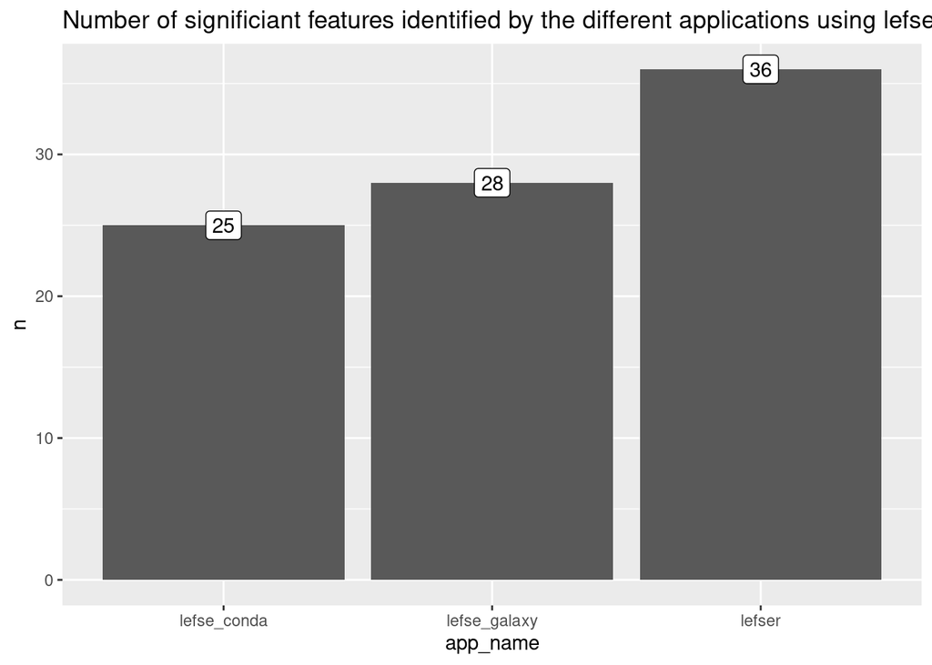

```r
combined_outputs <- bind_rows(lefse_conda, lefse_galaxy, lefser_output) %>%
    mutate(LDA = coalesce(lefse_conda_LDA, lefse_galaxy_LDA, lefser_LDA))

combined_outputs %>%
    count(app_name) %>%
    ggplot(aes(app_name, n)) +
    geom_col() +
    geom_label(aes(label = n)) +
    ggtitle(
        'Number of significiant features identified by the different applications using lefse'
    )
```

## Overlap of features reported as significant

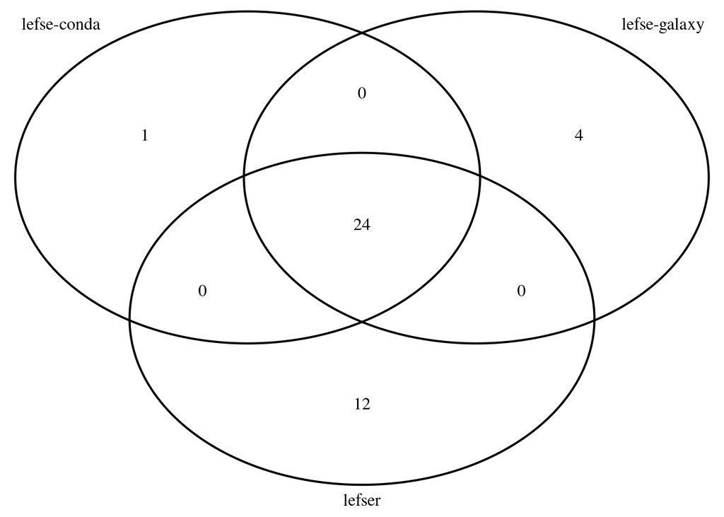

```r
set1 = lefse_conda$feature
set2 = lefse_galaxy$feature
set3 = lefser_output$feature

grid.newpage()
venn_object <- venn.diagram(
    x = list(set1, set2, set3),
    category.names = c("lefse-conda" , "lefse-galaxy" , "lefser"),
    filename = NULL
)
grid.draw(venn_object)
```

## LDA scores are similar

LDA scores of the 24 overlapping features are similar.

```r
joint_output <- purrr::reduce(
    .x = list(lefse_conda, lefse_galaxy, lefser_output),
    .f = ~ inner_join(.x, .y, by = 'feature')
) %>%
    select(feature, lefse_conda_LDA, lefse_galaxy_LDA, lefser_LDA)
joint_output
```

```
## # A tibble: 24 × 4
##    feature                           lefse_conda_LDA lefse_galaxy_LDA lefser_LDA
##    <chr>                                       <dbl>            <dbl>      <dbl>
##  1 g__Ruminococcus                             -3.51            -3.55      -3.52
##  2 o__Lactobacillales                          -3.24            -3.18      -3.26
##  3 f__Streptococcaceae                         -3.17            -3.08      -3.20
##  4 s__Ruminococcus_sp_5_1_39BFAA               -2.88            -2.89      -2.92
##  5 t__GCF_000159975                            -2.88            -2.89      -2.92
##  6 t__GCF_000173975                            -2.82            -2.81      -2.83
##  7 s__Eubacterium_hallii                       -2.82            -2.81      -2.83
##  8 t__Streptococcus_salivarius_uncl…           -2.68            -2.65      -2.66
##  9 s__Streptococcus_salivarius                 -2.68            -2.65      -2.66
## 10 t__GCF_000173455                            -2.27            -2.42      -2.17
## # … with 14 more rows
```

### lefser LDA scores vs lefse-conda LDA scores

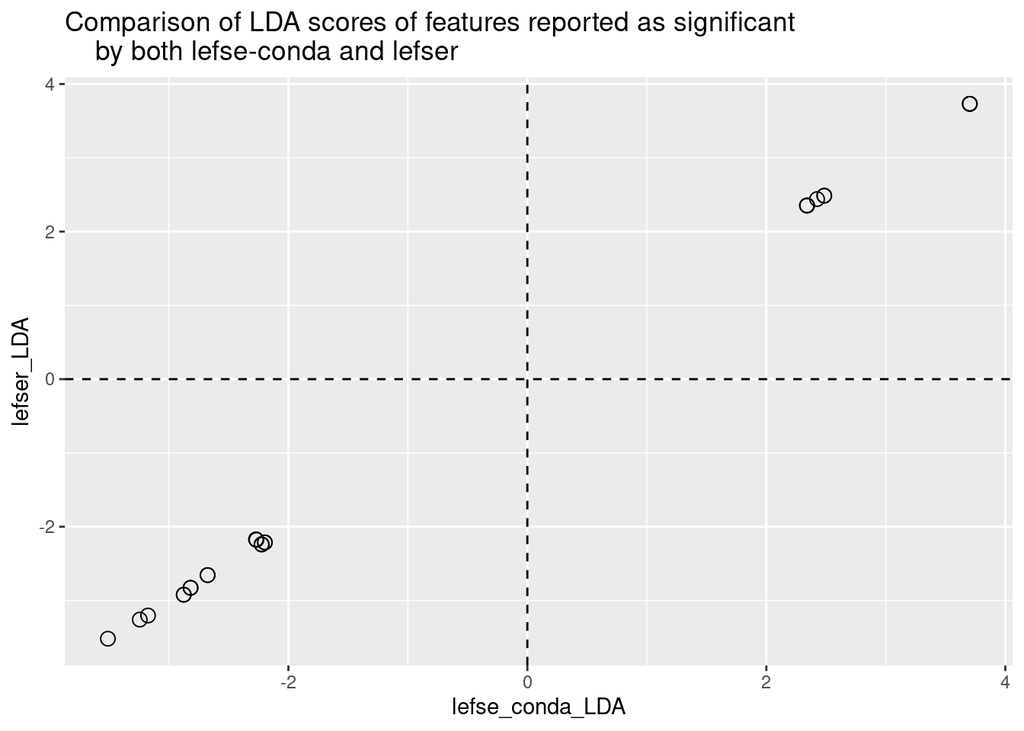

```r
joint_output %>%
    ggplot(aes(lefse_conda_LDA, lefser_LDA)) +
    geom_point(size = 3, shape = 1) +
    geom_hline(yintercept = 0, linetype = 'dashed') +
    geom_vline(xintercept = 0, linetype = 'dashed') +
    ggtitle(
    'Comparison of LDA scores of features reported as significant
    by both lefse-conda and lefser'
    )
```

### lefser LDA scores vs lefse-galaxy LDA scores

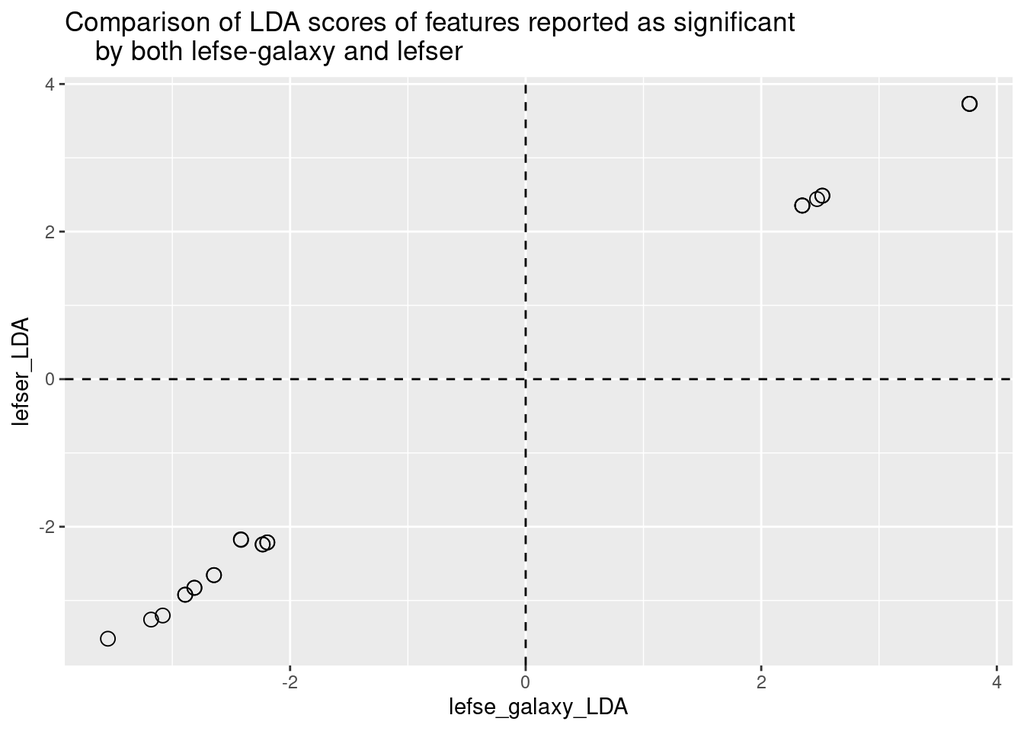

```r
joint_output %>%
    ggplot(aes(lefse_galaxy_LDA, lefser_LDA)) +
    geom_point(size = 3, shape = 1) +
    geom_hline(yintercept = 0, linetype = 'dashed') +
    geom_vline(xintercept = 0, linetype = 'dashed') +
    ggtitle(
    'Comparison of LDA scores of features reported as significant
    by both lefse-galaxy and lefser'
    )
```